# Task 2: Time Series (PELEGRI)

```r
knitr::opts_chunk$set(echo = TRUE, message = FALSE, warning = FALSE)

library(here)
library(tidyverse)
library(tsibble)
library(feasts)
library(slider)
library(lubridate)
```

## Overall

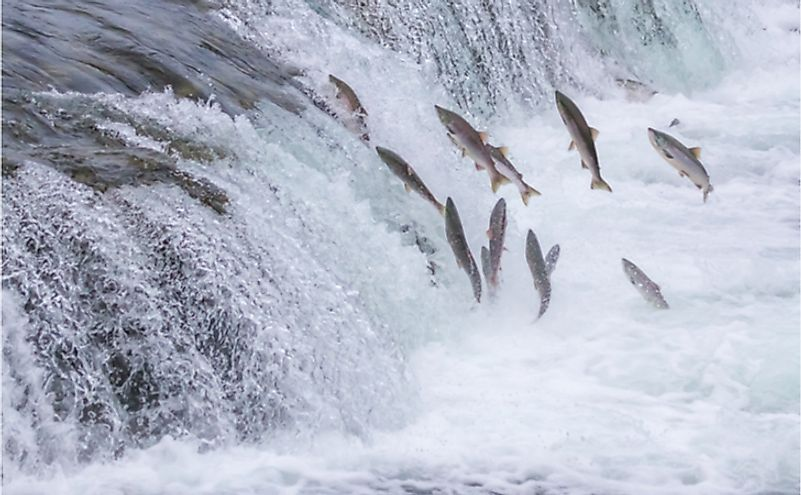

Salmon in Katmai National Park, Alaska. From World Atlas

Read in the data and perform initial wrangling

```r
fish_raw <- read_csv(here('data', 'willamette_fish_passage.csv'))

fish_ts <- fish_raw %>%
  janitor::clean_names() %>%
  mutate(date = mdy(date)) %>%
  as_tsibble(key = NULL, index = date) %>%
  select(coho, jack_coho, steelhead) %>%
  replace_na(list(coho = 0, jack_coho = 0, steelhead = 0)) %>%  # replace NA values with 0
  pivot_longer( # so that we can visualize them all on the same panel
    cols = coho:steelhead,
    names_to = "species",
    values_to = 'count'
  ) %>%
  mutate(species = case_when(
    species == 'coho' ~ "Coho",
    species == 'jack_coho' ~ "Jack Coho",
    species == 'steelhead' ~ "Steelhead"
  ))
```

### Original time series

Time series graph

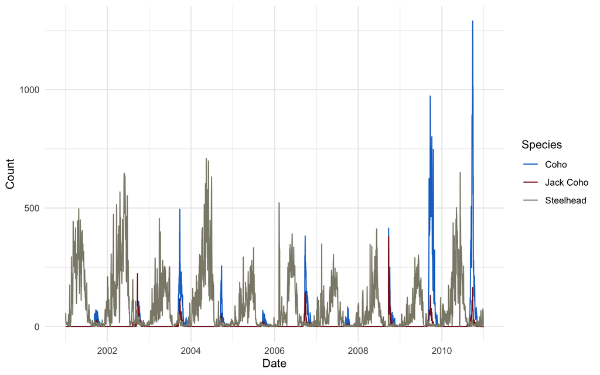

```r
ggplot(data = fish_ts, aes(x = date, y = count)) +
  geom_line(aes(color = species)) +
  labs(x = "Date",
       y = "Count",
       color = "Species") +
  scale_color_manual(values = c('dodgerblue3', 'firebrick4', 'cornsilk4')) +
  theme_minimal()
```

**Figure 1.** Time series plot of Coho, Jack Coho, and Steelhead counts at the Willamette Falls fish passage from 2001-2010.

**Figure 1 takeaways**

- The steelhead run has been the most consistent of the three species observed, and the steelhead run occurs at a different time of year than the coho and jack coho.
- The coho run has been inconsistent from year to year but in large years has had the highest counts of the three species. The jack coho had the smallest runs of the three species on average.
- The jack coho and coho runs appear to occur at the same time of year.

### Season plots

Plot season plot

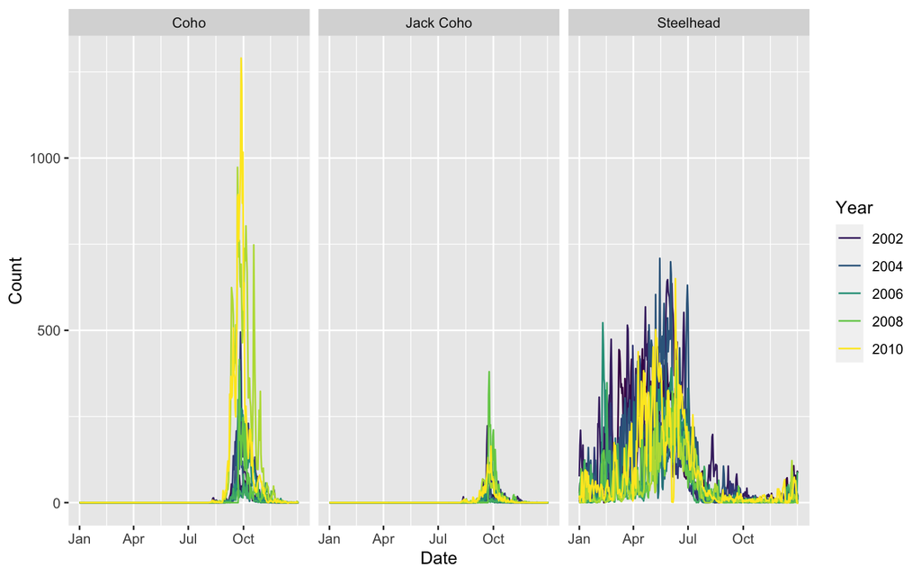

```r
gg_season(data = fish_ts, y = count) +
  scale_color_viridis_c(breaks = c(0, 2, 4, 6, 8, 10), labels = c(2000, 2002, 2004, 2006, 2008, 2010)) +
  facet_wrap(~species) +
  labs(y = "Count", x = "Date", color = "Year")
```

**Figure 2 takeaways**

- Coho and Jack Coho have a distinct peak in counts around October. Counts were closer to 0 the rest of the year.
- Steelhead counts are more evenly distributed throughout the year than Coho and Jack Coho. Steelhead counts peak around June and are lowest from roughly September to November.

### Annual counts by species

Prepare data for plot

```r
fish_counts_df <- fish_raw %>%

  # This code repeats what we did to create fish_ts without making it a ts
  janitor::clean_names() %>%
  mutate(date = mdy(date)) %>%
  select(coho, jack_coho, steelhead, date) %>%
  replace_na(list(coho = 0, jack_coho = 0, steelhead = 0)) %>%
  pivot_longer(
    cols = coho:steelhead,
    names_to = "species",
    values_to = 'count'
  ) %>%
  mutate(species = case_when(
    species == 'coho' ~ "Coho",
    species == 'jack_coho' ~ "Jack Coho",
    species == 'steelhead' ~ "Steelhead"
  )) %>%

  # This code is for creating counts by year
  mutate(year = year(date)) %>%
  select(-date) %>%
  group_by(year, species) %>%
  summarize(annual_count = sum(count))
```

Plot annual counts by species

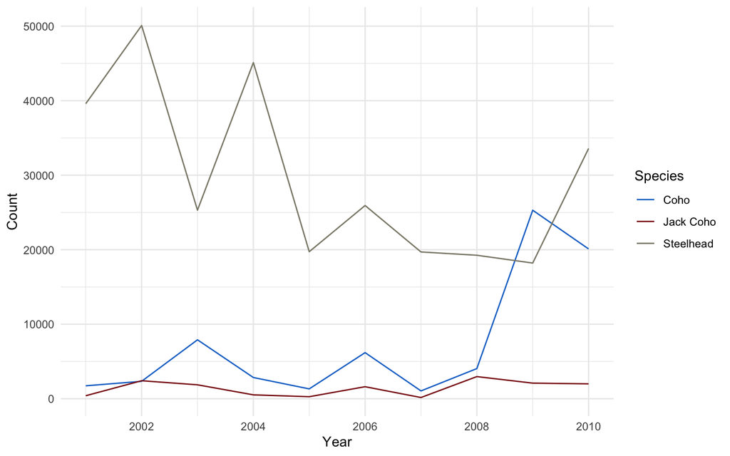

```r
ggplot(fish_counts_df) +
  geom_line(aes(x = year, y = annual_count, color = species)) +
  scale_color_manual(values = c('dodgerblue3', 'firebrick4', 'cornsilk4')) +
  theme_minimal() +
  scale_x_continuous(breaks = scales::pretty_breaks(5)) +
  labs(x = "Year", y = 'Count', color = 'Species')
```

**Figure 3.** Annual counts of Coho, Jack Coho, and Steelhead at Willamette Falls fish passage from 2001 to 2010